# Tugas Praktikum MPDW

Thoriq Ar Ridfi

NIM: M0401241057

# 1 PENDAHULUAN

## 1.1 Latar Belakang

Analisis deret waktu (*time series analysis*) merupakan salah satu metode kuantitatif penting untuk mempelajari pola historis dan meramalkan kondisi masa depan. Metode **Autoregressive Integrated Moving Average (ARIMA)** atau pemodelan Box-Jenkins banyak diterapkan pada data linier, baik yang stasioner maupun yang membutuhkan tahapan diferensiasi (*differencing*).

# 2 METODOLOGI & IMPORT DATA

## 2.1 Import Dataset Cuaca

Dataset yang digunakan memuat data observasi cuaca per jam (minimal 500 amatan). Variabel yang dianalisis adalah **Suhu Rata Rata (°C)** pada kolom C.

```r
# Load Package
library(readxl)
library(TSA)
library(tseries)
library(forecast)
library(MASS)
library(lmtest)
library(ggplot2)
library(plotly)
library(DT)
library(dplyr)

# Import Data
df <- read_excel("C:\\Users\\TUF GAMING\\Downloads\\data_cuaca_bogor.xlsx")

# Mengambil variabel amatan
y <- df$`Suhu Rata Rata (°C)`
n_total <- length(y)

cat("Total amatan data cuaca:", n_total, "jam\n")
```

```
## Total amatan data cuaca: 12384 jam
```

## 2.2 Pembagian Data Train dan Data Test

Dataset dipisah menjadi **Data Train** (85%) untuk pembentukan model dan **Data Test** (15%) untuk pengujian akurasi ramalan. Data diubah ke objek *time series* dengan `frequency = 24` karena berulang setiap siklus 24 jam.

```r
# Pembagian data (85% Train, 15% Test)
prop_train <- 0.85
n_train <- round(prop_train * n_total)
n_test  <- n_total - n_train

train <- y[1:n_train]
test  <- y[(n_train + 1):n_total]

# Objek time series frekuensi 24 jam
train_ts <- ts(train, frequency = 24)
test_ts  <- ts(test, start = (n_train / 24) + 1, frequency = 24)

# Visualisasi Interaktif Pembagian Data
df_plot <- data.frame(
  Waktu = 1:n_total,
  Suhu  = y,
  Kelompok = c(rep("Data Train", n_train), rep("Data Test", n_test))
)

p_split <- ggplot(df_plot, aes(x = Waktu, y = Suhu, color = Kelompok)) +
  geom_line(linewidth = 0.6) +
  scale_color_manual(values = c("Data Train" = "#2b6cb0", "Data Test" = "#e53e3e")) +
  labs(
    title = "Plot Pembagian Data Train dan Data Test (Suhu Per Jam)",
    x = "Jam ke-",
    y = "Suhu Rata-Rata (°C)",
    color = "Kelompok Data"
  ) +
  theme_minimal()

ggplotly(p_split)
```

[interactive chart not shown]

# 3 DIAGNOSTIK STASIONERITAS DATA

## 3.1 Stasioneritas Ragam (Box-Cox)

Pemeriksaan ragam dilakukan melalui grafik transformasi Box-Cox. Data stasioner dalam ragam apabila nilai $\lambda = 1$ terlingkup dalam interval kepercayaan 95%.

```r
bc <- boxcox(train_ts ~ 1, plotit = FALSE)
lambda <- bc$x[which.max(bc$y)]
ci <- range(bc$x[bc$y > max(bc$y) - 0.5 * qchisq(0.95, 1)])

cat("Nilai Lambda Optimal :", lambda, "\n")
```

```
## Nilai Lambda Optimal : -2
```

```r
cat("Interval CI 95% Lambda : [", ci[1], ",", ci[2], "]\n")
```

```
## Interval CI 95% Lambda : [ -2 , -2 ]
```

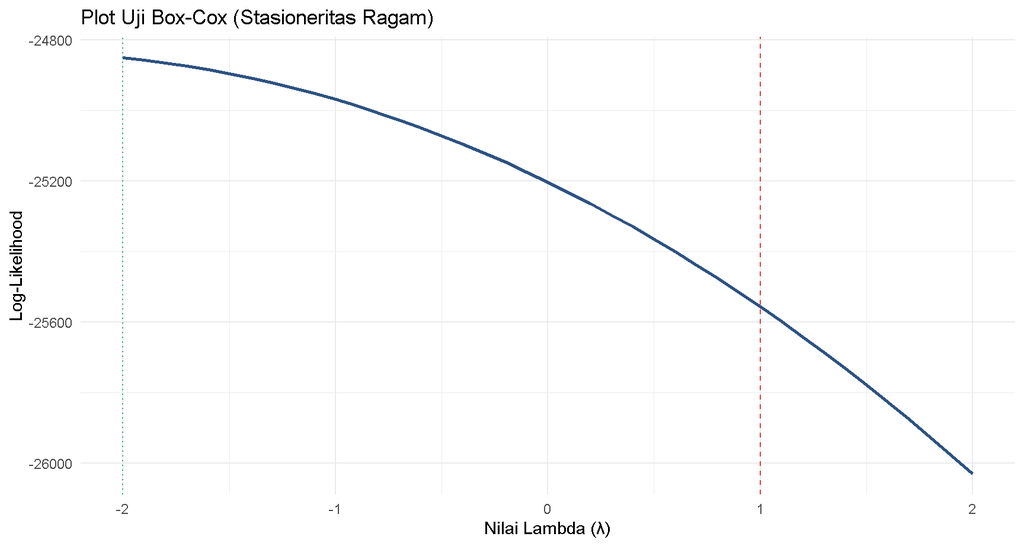

```r
df_bc <- data.frame(Lambda = bc$x, LogLik = bc$y)
p_bc <- ggplot(df_bc, aes(x = Lambda, y = LogLik)) +
  geom_line(color = "#2c5282", linewidth = 1) +
  geom_vline(xintercept = 1, linetype = "dashed", color = "#e53e3e") +
  geom_vline(xintercept = lambda, color = "#38a169", linetype = "dotted") +
  labs(title = "Plot Uji Box-Cox (Stasioneritas Ragam)", x = "Nilai Lambda (λ)", y = "Log-Likelihood") +
  theme_minimal()

print(p_bc)
```

## 3.2 Stasioneritas Rataan (Plot ACF & Uji ADF)

Kestasioneran rataan diperiksa dengan grafik ACF awal dan **Uji Augmented Dickey-Fuller (ADF)**.

```r
adf_test <- adf.test(train_ts)
print(adf_test)
```

```
##
##  Augmented Dickey-Fuller Test
##
## data:  train_ts
## Dickey-Fuller = -7.397, Lag order = 21, p-value = 0.01
## alternative hypothesis: stationary
```

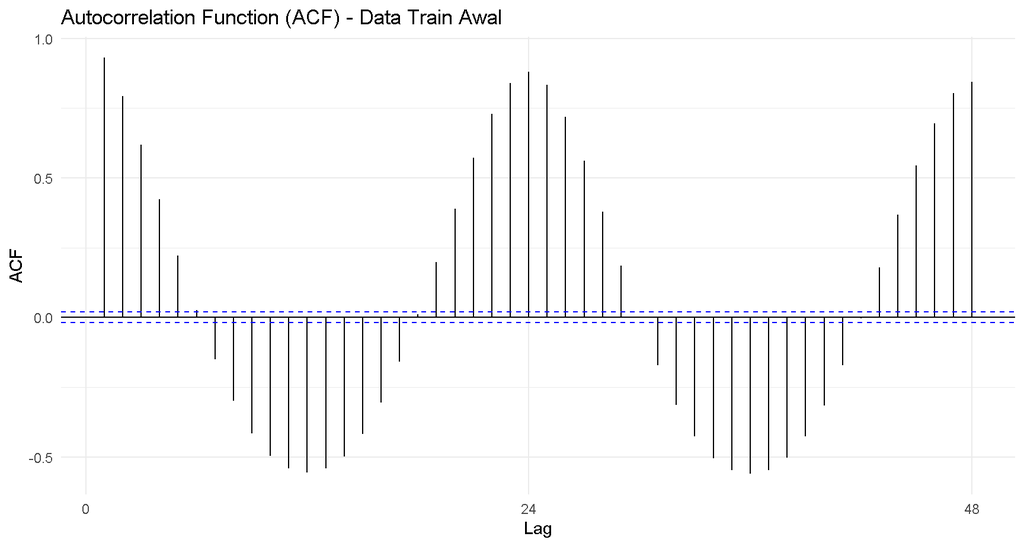

```r
ggAcf(train_ts, lag.max = 48) +
  labs(title = "Autocorrelation Function (ACF) - Data Train Awal") +
  theme_minimal()
```